# Exercise_08_BC

Betsy Cowdery

October 27, 2014

## Case Study: Lab 4 pine cones data

```r
load("data/Lab8_cone.RData")
```

### AIC vs Likelihood Ratio Test

**Lab Report Task 1** Compare the AICs for the two models, interpret the results for this test, and compare with the results from the LRT previously performed.

```
## [1] "Combined treatments ACI : 2600.006054"
```

```
## [1] "Separate treatments ACI : 2555.858033"
```

#### Compare the AICs for the two models, interpret the results for this test, and compare with the results from the LRT previously performed.

### Bootstrapped Interval Estimates

**Lab Report Task 2** Generate density and CI plots for all 3 model parameters. Include three figures and a table of parameter estimates, standard errors, and CI.

```
## [1] 100
```

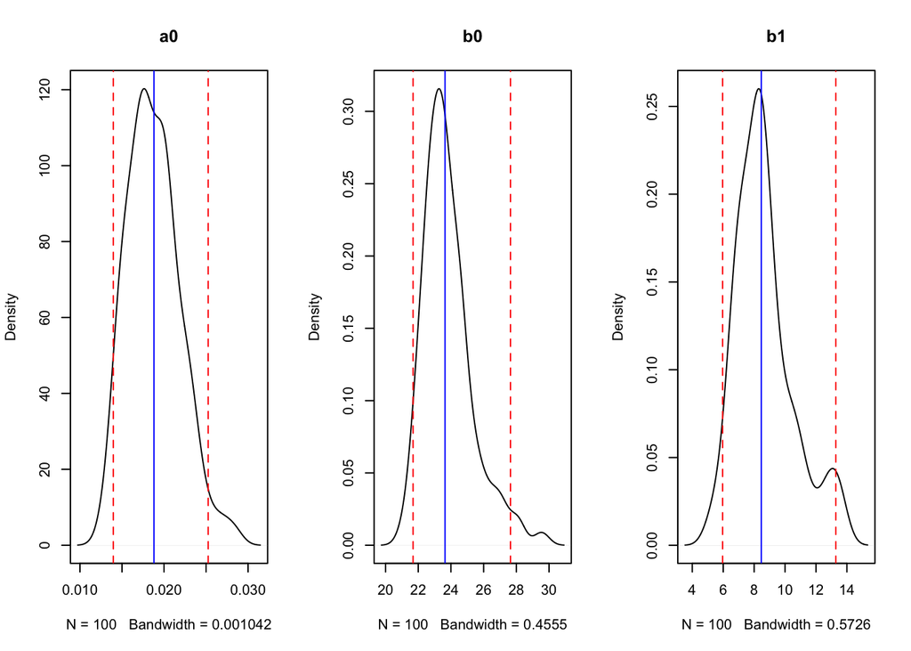

```
## [1] 100
```

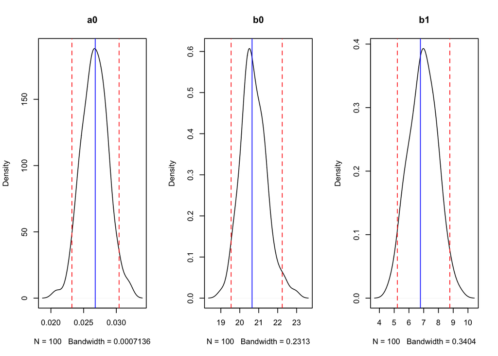

```
##               a0        SE    2.5%   97.5%
## Ambient  0.01878 9.552e-07 0.01397 0.02526
## Elevated 0.02669 4.021e-07 0.02321 0.03042
```

```
##             b0      SE  2.5% 97.5%
## Ambient  23.82 0.22998 21.68 27.64
## Elevated 20.72 0.04658 19.54 22.24
```

```
##             b1      SE  2.5%  97.5%
## Ambient  8.667 0.34811 5.963 13.285
## Elevated 6.948 0.09026 5.216  8.769
```

### Model Intervals

**Lab Report Task 3** Plot the confidence and predictive interval for the maturation process model. Include both this plot and the fecundity plot in your lab report.

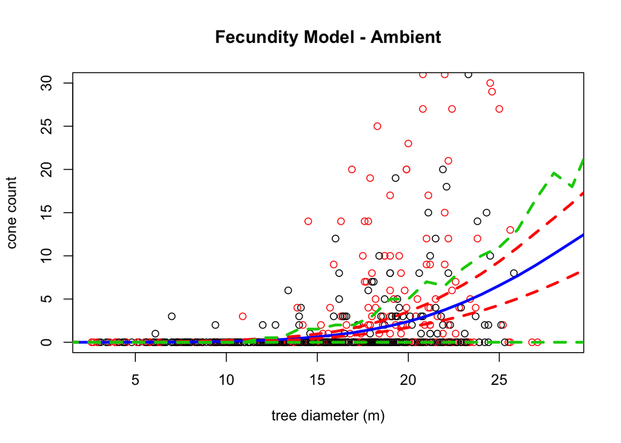

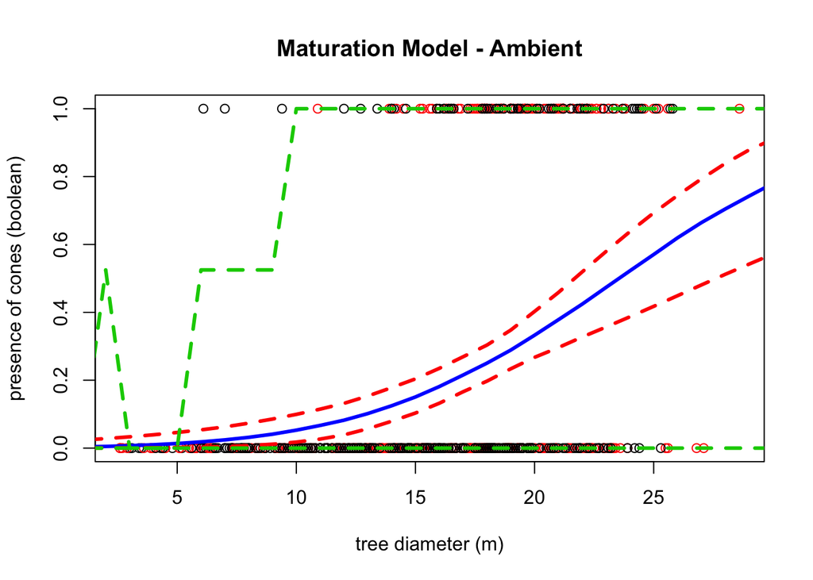

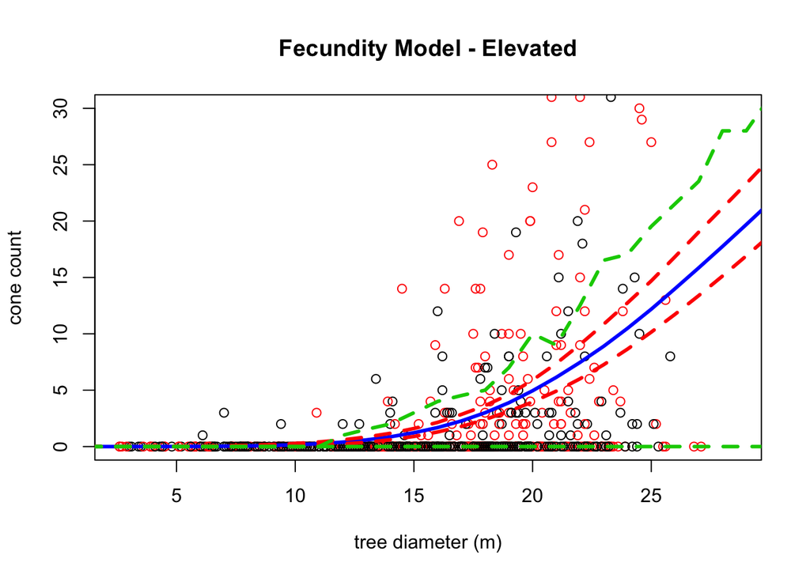

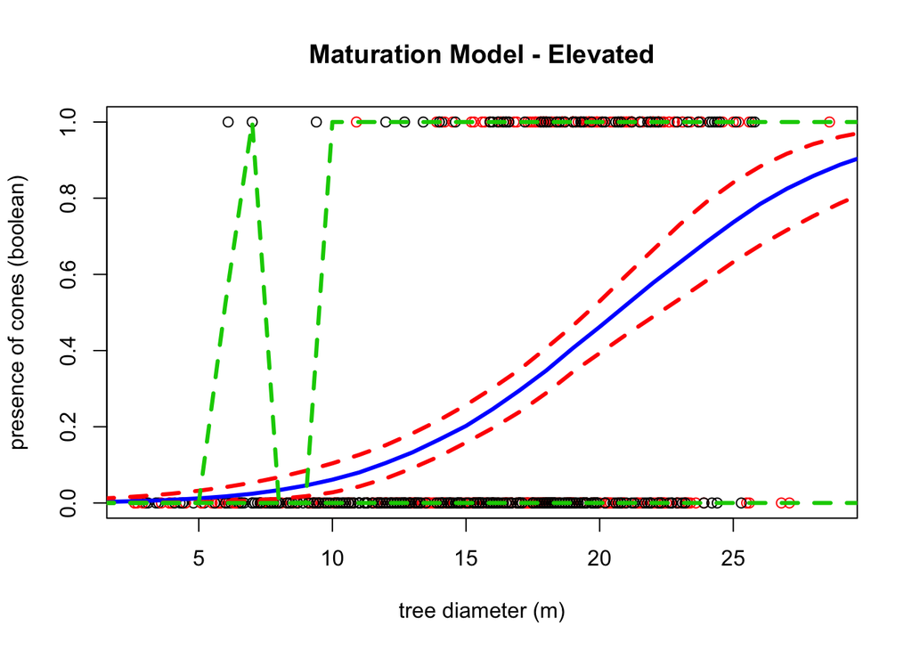

** Lab Report Task 4 ** Repeat the bootstrap analysis for the elevated CO2 treatment. Include the figures and tables from tasks 2 & 3 for the elevated plots as well as a final plot that compares the model confidence intervals between the elevated and ambient data on one figure

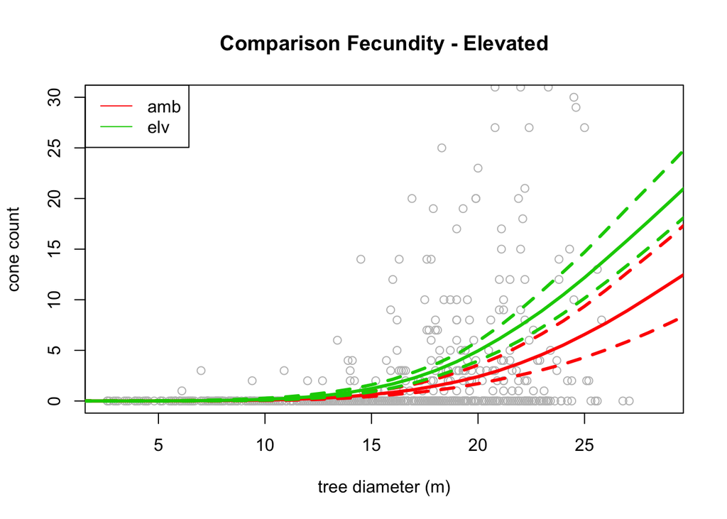

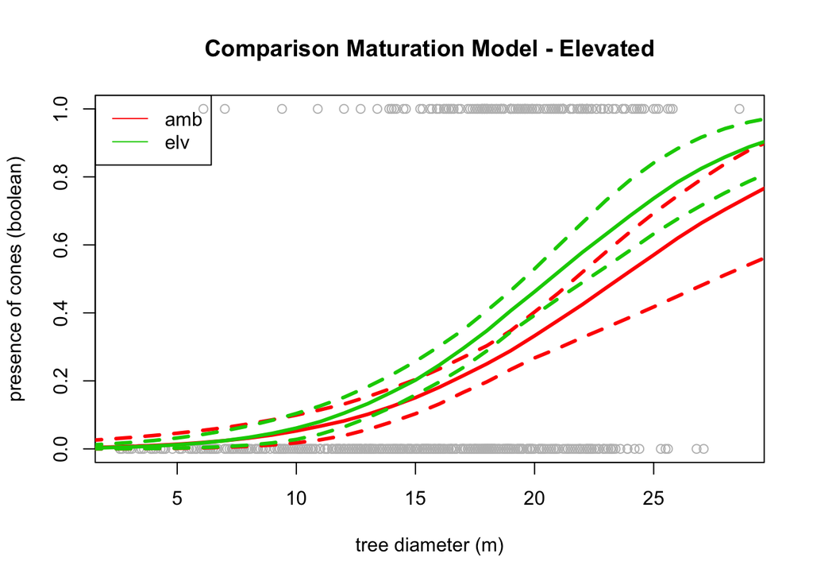

**Extra Credit: Likelihood Profile Interval Estimates: Lab 3 Fire Scar data**

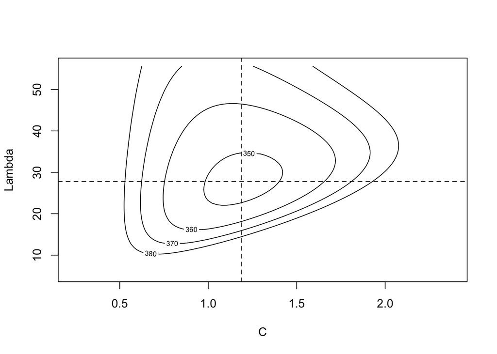

**Lab Report Task 5** Modify the previous section of code to calculate the vector c.like, that is found by fixing the value of C and fitting using the prof_c likelihood function. Be aware that you will need to flip many components of the code, including the order of the two variables in the “points” command. Turn in the following:

- R code for calculating c.like
- Likelihood surface plot that has the points for BOTH the profile of lambda and the profile of C

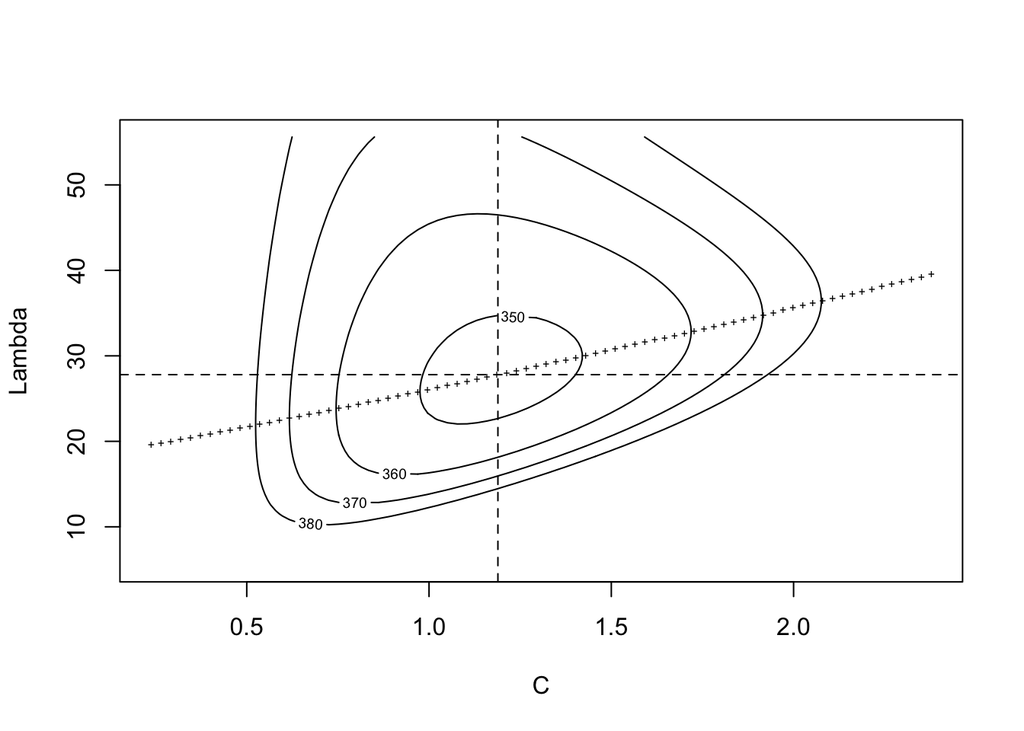

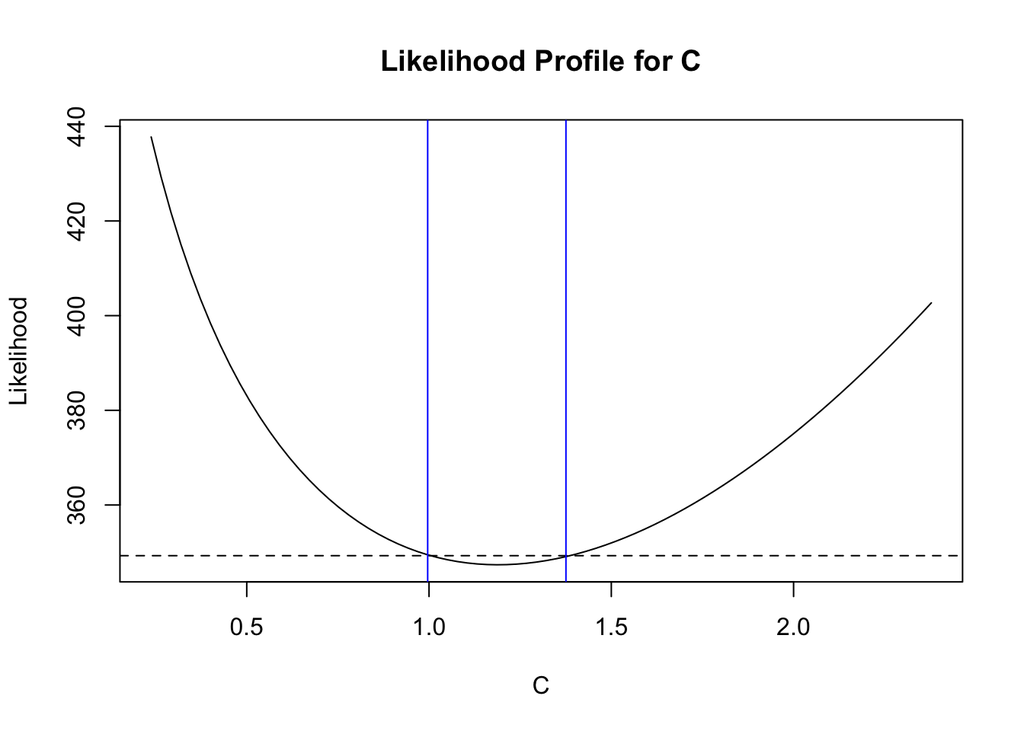

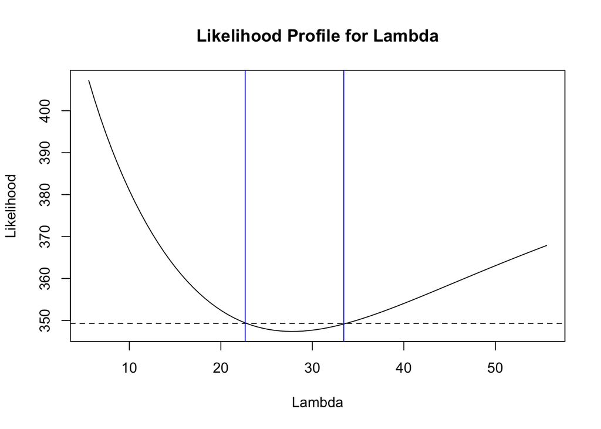

```r
cs      = c_mle*rp        ## sequence of c values being evaluated
c.like  = numeric(nstep)        ## storage for c likelihood values
LgivenC = numeric(nstep)     ## storage for the lambda value that pairs with c
for(i in 1:nstep){                  ## set c, solve for MLE
  lout <- optimize(
    prof_c,
    interval=range(lam_mle*rp),
    maximum=FALSE,
    c=cs[i]
    )
  c.like[i] <- lout$objective      ## save the likelihood
  LgivenC[i] = lout$minimum ## save the MLE of lambda
  }
contour(rp*c_mle,rp*lam_mle,z,levels=c(350,360,370,380),xlab="C",ylab="Lambda")
abline(v=c_mle,lty=2)
abline(h=lam_mle,lty=2)
lines(cs,LgivenC,type='b',pch="+",cex=0.5) ## add points to the contour plot
```

** Lab Report Task 6** Modify the previous section of code to calculate the CI for lambda as well. Turn in the likelihood profile plots with the CI and threshold for both variables and report the numeric values for the MLE and CI for both parameters

```
##           2.5%    MLE   97.5
## c       0.9963  1.186  1.376
## lambda 22.6631 27.731 33.432
```